# a3_task3_michelle_leporibui

Michelle Lepori-Bui

11/2/2020

# Santa Barbara Urchins

## Section 1: Comparing sizes of red and purple urchins

In this section, we compare red and purple urchin sizes visually using two different plot types.

The histogram shows us the frequency distribution of urchin sizes, and the box plot shows summary statistics of median, quartiles, and outliers of urchin size.

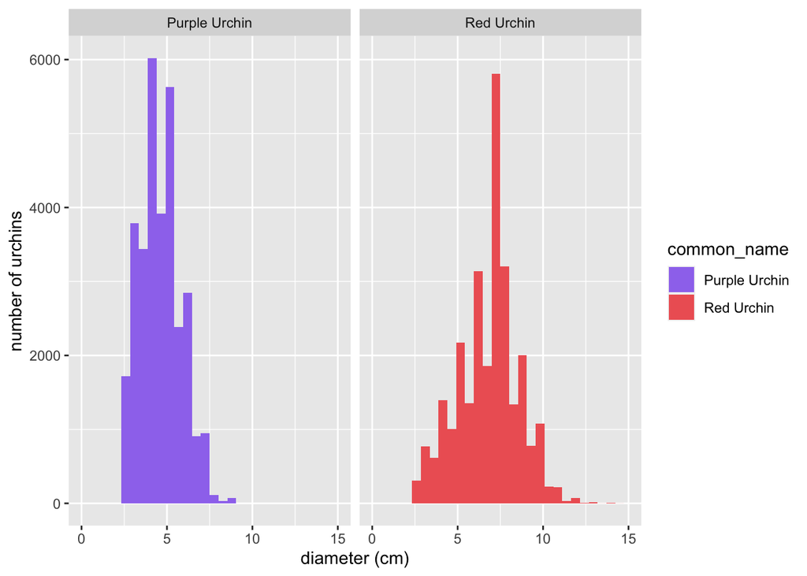

```r
# first use janitor::clean_names() to standardize column names
urchins_clean <- urchins %>%
  clean_names()

# make histograms of all urchin diameters divided by species common name
ggplot(data = urchins_clean, aes(x = size)) +
  geom_histogram(aes(fill = common_name)) +
  scale_fill_manual(values = c("mediumpurple2","indianred2")) +
  xlim(0,15) +
  facet_wrap(~common_name) +
  labs (x = "diameter (cm)", y = "number of urchins")
```

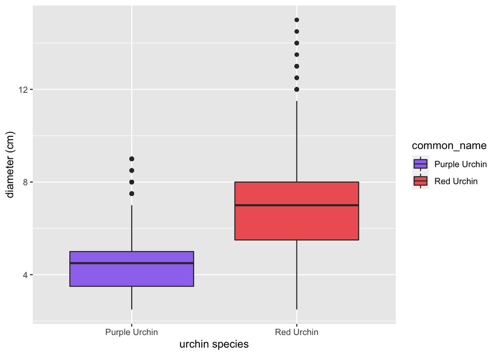

```r
# make boxplots of of all urchin diameters divided by species common name
ggplot(data = urchins_clean, aes(x = common_name, y = size)) +
  geom_boxplot(aes(fill = common_name)) +
  scale_fill_manual(values = c("mediumpurple2","indianred2")) +
  labs( x =  "urchin species", y = "diameter (cm)")
```

Next we calculate and create a table of summary statistics for purple and red urchins.

```r
# clean colum names, group by species common name, and calculate mean, median, standard deviation, and number of samples or urchin diameter
urchins_summary <- urchins_clean %>%
  group_by(common_name) %>%
  summarize(urch_mean = mean(size),
            urch_med = median(size),
            urch_sd = sd(size),
            urch_n = n())

#clean up table using kableExtra::kable()
urchins_summary %>%
  kable(col.names = c("species", "mean", "median", "standard deviation", "sample size")) %>%
  kable_styling()
```

| species | mean | median | standard deviation | sample size |
| --- | --- | --- | --- | --- |
| Purple Urchin | 4.469797 | 4.5 | 1.175264 | 31805 |
| Red Urchin | 6.776489 | 7.0 | 1.891343 | 27408 |

Analysis: By looking at the plots, we can see that purple urchins tend to be smaller and more uniform in size than red urchins, which look to be slightly larger on average, have more variation, and a few more large outliers.

From the summary statistics, we know the mean diameter of purple urchins is roughly 34% lower than red urchins and have a smaller standard deviation.

## Section 2: Purple Urchins

In this section we will look more closely at how many urchins were sampled at each site over time.

First, we write out each of the 5 site names and edit the dates for easier data analysis.

```r
# clean column names, change data format and make a new year column
# then, add new column for full site names based on their abbreviations
purple_urchins <- urchins_clean %>%
  filter(common_name == "Purple Urchin") %>%
  mutate(date = mdy(date)) %>%
  mutate(year = year(date)) %>%
  mutate(site_full = case_when(
    site == "NAPL" ~ "Naples Reef",
    site == "AQUE" ~ "Arroyo Quemado Reef",
    site == "CARP" ~ "Carpinteria Reef",
    site == "MOHK" ~ "Mohawk Reef",
    site == "IVEE" ~ "Isla Vista Reef"
  ))
```

Next, we summarize counts for each site and year.

```r
# group by site and year, summarizy by number of samples
purple_urchins_summary <- purple_urchins %>%
  group_by(site_full, year) %>%
  summarize(count = n()) # checked to make sure it worked but not calling output to show up here
```

Last, we compare the number of urchins sampled over time at each site.

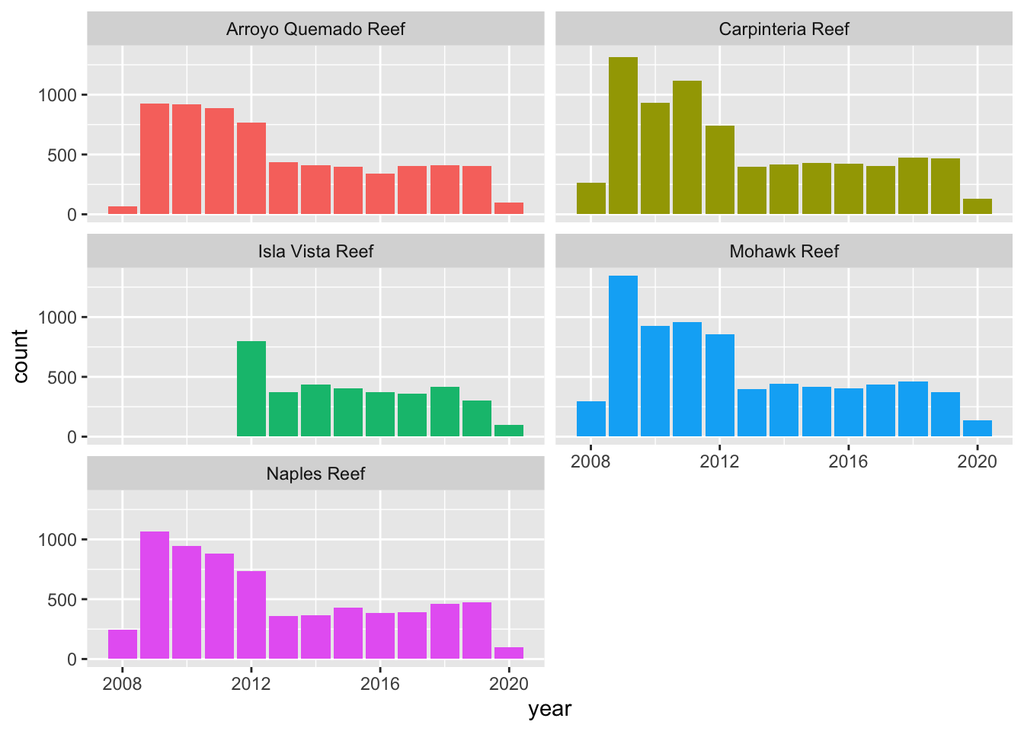

```r
# plot number of samples over time for each site seperately
ggplot(data = purple_urchins_summary, aes(x = year, y = count)) +
  geom_col(aes(fill = site_full)) +
  facet_wrap(~site_full, ncol = 2) +
  theme(legend.position = "none")
```

These plots show that at all sites (except Isla Vista Reef, which does not have data from this time period), there were more samples collected between the years 2009-2012, and fewer samples in general in all the years after that. The lowest sampling years for all sites were the first and last recorded, 2008 and 2020 (except for Isla Vista Reef which does not have reported counts for 2008).